# R Notebook

Exercise 3-1 #############

We have 2 continous variable from hicker smarthphone. dist -> Distance (in km) alti -> Altitude (in m)

1. Calculate the arithmetic mean and median for both distance and altitude

Mean, Median for Distance

```r
dist<-c(12.5,29.9,14.8,18.7,7.6,16.2,16.5,27.4,12.1,17.5)
mean(dist)
```

```
## [1] 17.32
```

```r
median(dist)
```

```
## [1] 16.35
```

Mean, Median for Altitude

```r
alti<-c(342,1245,502,555,398,670,796,912,238,466)
mean(alti)
```

```
## [1] 612.4
```

```r
median(alti)
```

```
## [1] 528.5
```

2. Determine the first and third quartiles for both distance and the altitude variables Discuss the shape of the distribution give the result of (a) and (b)

Quartiles for distance

```r
quantile(dist,probs=c(0.25,0.75),type=2)
```

```
##  25%  75%
## 12.5 18.7
```

To achieve correct quantile type 2 algorithm was used (default is 7).

```r
quantile(alti,probs=c(0.25,0.75),type=2)
```

```
## 25% 75%
## 398 796
```

What does it means? Distance. Mean is higher than median and mean in higher range of 25% and 75% quantile. It means there were some trip(s) with longer length than others.

Altitude. Mean is in the middle of 25% and 75% range. Mean is much higher than average, so we have some trips with mich higher altitude move then others.

Interquartile range for distance

```r
  quantile(dist,probs=c(0.75),type=2) - quantile(dist,probs=c(0.25),type=2)
```

```
## 75%
## 6.2
```

```r
  quantile(alti,probs=c(0.75),type=2) - quantile(alti,probs=c(0.25),type=2)
```

```
## 75%
## 398
```

Absolute median deviation

Distance.

```r
dist<-c(12.5,29.9,14.8,18.7,7.6,16.2,16.5,27.4,12.1,17.5)
m<-median(dist)
dist = dist - m
dist = abs(dist)
sum(dist)/length(dist)
```

```
## [1] 4.68
```

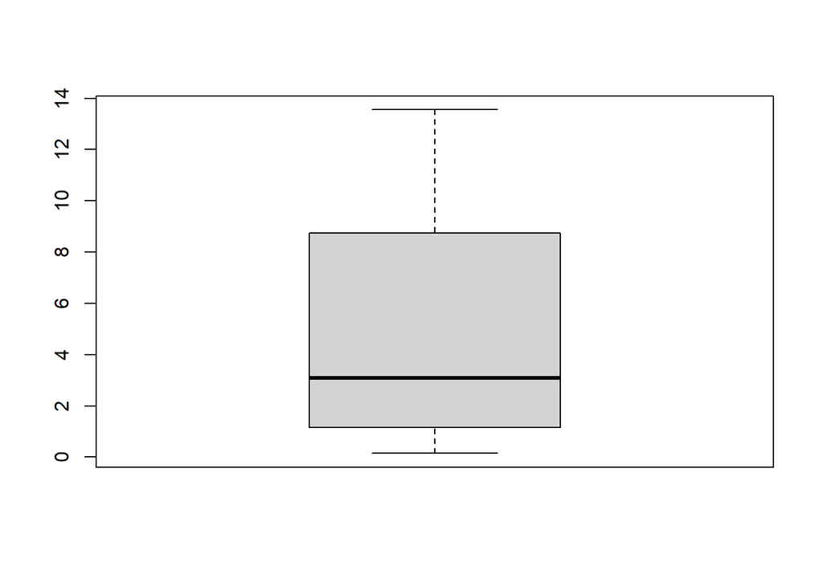

```r
boxplot(dist,range=1.5)
```

Boxplot for altitude

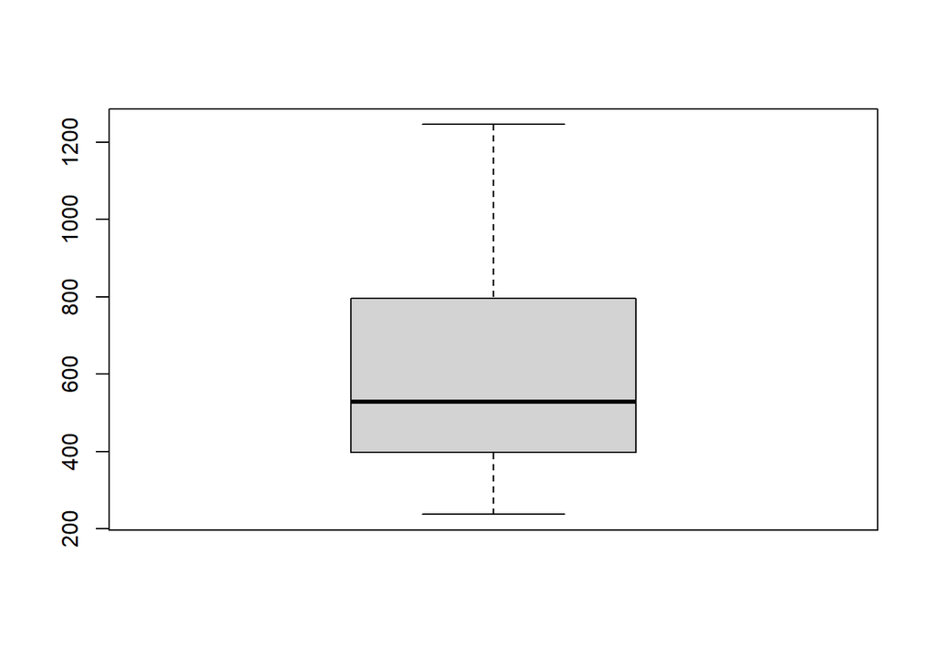

```r
boxplot(alti,range=1.5)
```

6. Parameters for grouped data. Calculate the weighted arithmetic data, weighted median

Weight arithmetic mean

```r
weighted.mean(c(10,17.5,25),c(0.4,0.4,0.2))
```

```
## [1] 16
```

Weight median (values are equally distributed) Sum all relative frequencies and stop when > 0.5 median = 15 + ((0.5) - 0.4 /0.4) * 5 = 15 + (0.1/0.4) * 5 = 15 + 0.25 * 5 = 15 + 1.25 = 16.25

Is there any way in R to support this automatically ?